# Self-Driving Car Engineer Nanodegree

## Project: Build a Traffic Sign Recognition Classifier

In this notebook, a template is provided for you to implement your functionality in stages, which is required to successfully complete this project. If additional code is required that cannot be included in the notebook, be sure that the Python code is successfully imported and included in your submission if necessary.

In addition to implementing code, there is a writeup to complete. The writeup should be completed in a separate file, which can be either a markdown file or a pdf document. There is a [write up template](https://github.com/udacity/CarND-Traffic-Sign-Classifier-Project/blob/master/writeup_template.md) that can be used to guide the writing process. Completing the code template and writeup template will cover all of the [rubric points](https://review.udacity.com/#!/rubrics/481/view) for this project.

The [rubric](https://review.udacity.com/#!/rubrics/481/view) contains "Stand Out Suggestions" for enhancing the project beyond the minimum requirements. The stand out suggestions are optional. If you decide to pursue the "stand out suggestions", you can include the code in this Ipython notebook and also discuss the results in the writeup file.

> **Note:** Code and Markdown cells can be executed using the **Shift + Enter** keyboard shortcut. In addition, Markdown cells can be edited by typically double-clicking the cell to enter edit mode.

## Step 0: Load The Data

```python
# Load pickled data
import pickle
import numpy as np
import pandas as pd
import matplotlib.pyplot as plt
import cv2
import tensorflow as tf
# TODO: Fill this in based on where you saved the training and testing data

training_file = 'train.p'
validation_file= 'valid.p'
testing_file = 'test.p'

with open(training_file, mode='rb') as f:
    train = pickle.load(f)
with open(validation_file, mode='rb') as f:
    valid = pickle.load(f)
with open(testing_file, mode='rb') as f:
    test = pickle.load(f)

#X_train, y_train = np.array(train['features'], dtype = np.float64), train['labels']
X_train, y_train = train['features'], train['labels']
X_valid, y_valid = valid['features'], valid['labels']
X_test, y_test = test['features'], test['labels']
```

## Step 1: Dataset Summary & Exploration

The pickled data is a dictionary with 4 key/value pairs:

- `'features'` is a 4D array containing raw pixel data of the traffic sign images, (num examples, width, height, channels).
- `'labels'` is a 1D array containing the label/class id of the traffic sign. The file `signnames.csv` contains id -> name mappings for each id.
- `'sizes'` is a list containing tuples, (width, height) representing the original width and height the image.
- `'coords'` is a list containing tuples, (x1, y1, x2, y2) representing coordinates of a bounding box around the sign in the image. **THESE COORDINATES ASSUME THE ORIGINAL IMAGE. THE PICKLED DATA CONTAINS RESIZED VERSIONS (32 by 32) OF THESE IMAGES**

Complete the basic data summary below. Use python, numpy and/or pandas methods to calculate the data summary rather than hard coding the results. For example, the [pandas shape method](http://pandas.pydata.org/pandas-docs/stable/generated/pandas.DataFrame.shape.html) might be useful for calculating some of the summary results.

### Provide a Basic Summary of the Data Set Using Python, Numpy and/or Pandas

```python
### Replace each question mark with the appropriate value.
### Use python, pandas or numpy methods rather than hard coding the results

# TODO: Number of training examples
n_train = len(y_train)

# TODO: Number of validation examples
n_validation = len(y_valid)

# TODO: Number of testing examples.
n_test = len(y_test)

# TODO: What's the shape of an traffic sign image?
image_shape = X_train[0].shape

# TODO: How many unique classes/labels there are in the dataset.
# I will also need indices and counts for every class.
sign_classes, class_indices, class_counts = np.unique(y_train, return_index = True, return_counts = True)
n_classes = len(sign_classes)

print("Number of training examples =", n_train)
print("Number of testing examples =", n_test)
print("Image data shape =", image_shape)
print("Number of classes =", n_classes)
```

```
Number of training examples = 34799
Number of testing examples = 12630
Image data shape = (32, 32, 3)
Number of classes = 43
```

### Include an exploratory visualization of the dataset

Visualize the German Traffic Signs Dataset using the pickled file(s). This is open ended, suggestions include: plotting traffic sign images, plotting the count of each sign, etc.

The [Matplotlib](http://matplotlib.org/) [examples](http://matplotlib.org/examples/index.html) and [gallery](http://matplotlib.org/gallery.html) pages are a great resource for doing visualizations in Python.

**NOTE:** It's recommended you start with something simple first. If you wish to do more, come back to it after you've completed the rest of the sections. It can be interesting to look at the distribution of classes in the training, validation and test set. Is the distribution the same? Are there more examples of some classes than others?

```python
### Data exploration visualization code goes here.
### Feel free to use as many code cells as needed.
# Visualizations will be shown in the notebook.
%matplotlib inline
```

First I load the sign names. And show them.

```python
sign_names = pd.read_csv('signnames.csv')
```

Now plot the random image with it's class name.

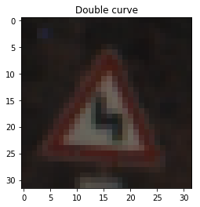

```python
def get_signname(idx):
    return sign_names.iloc[y_train[idx]]['SignName']
index = np.random.randint(0, X_train.shape[0])
rand_img = X_train[index]
rand_img_class = get_signname(index)
plt.title(rand_img_class)
plt.imshow(rand_img)
```

Now I want to see more samples. What exactly I want to see now, is one random image for every class. Since the image of one class has been plotted already, I won't plot it anymore

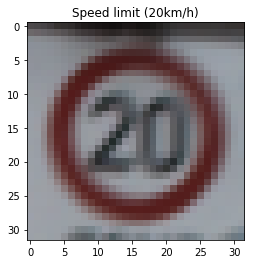

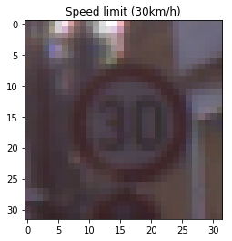

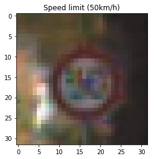

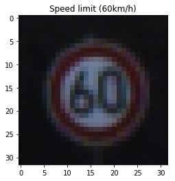

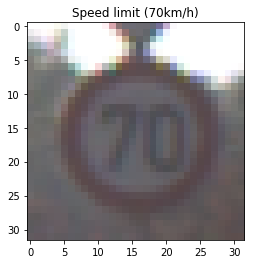

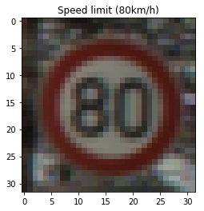

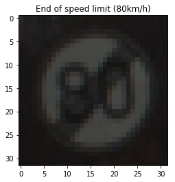

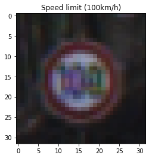

[figure not shown]

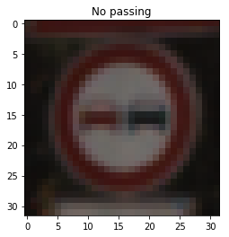

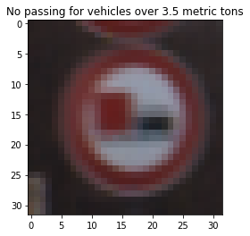

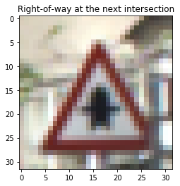

[30 more figures not shown]

```python
sign_classes_remain = np.delete(sign_classes, y_train[index])

for sign_class, start_index, count in zip(sign_classes_remain, class_indices, class_counts):
    sign_index = np.random.randint(start_index, start_index + count)
    plt.figure()
    plt.title(get_signname(sign_index))
    plt.imshow(X_train[sign_index])
```

This step was quite useful. Now I know that not all the signs are nicely centered. Some of the images are rotated, some of them are zoomed and some are sheared. A lot of pictures were taken at nighttime, so there is probably no need of keeping 3 color channels.

Now I want to see the bar plot showing number of training images for every class.

```
<Container object of 43 artists>
```

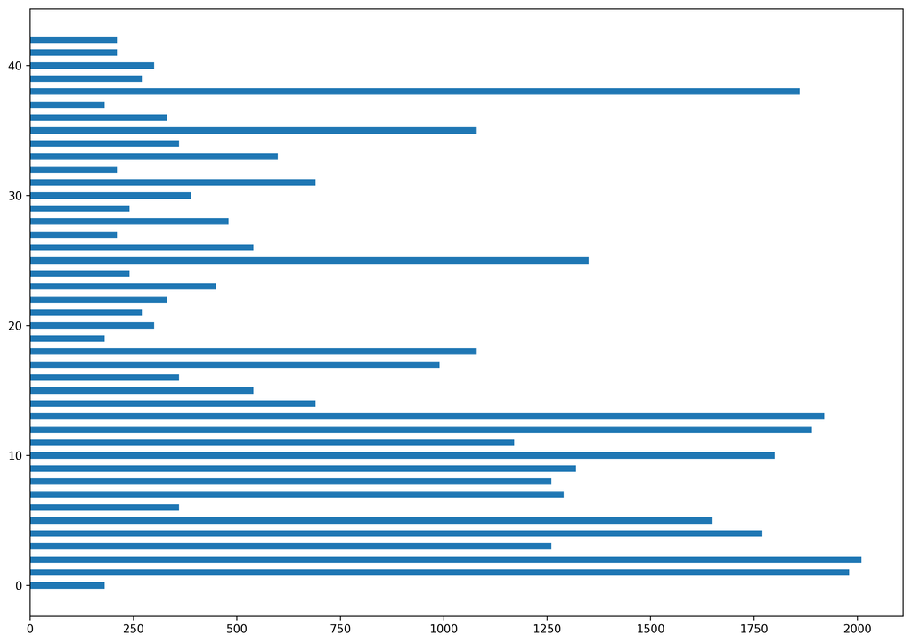

```python
plt.figure(num=None, figsize=(14, 10), dpi=320, facecolor='w', edgecolor='k')
plt.barh(sign_classes, class_counts, height = 0.5)
```

This step is very useful for future data augmentation. There is a large white space in this bar plot. It means that some classes are represented by larger set of samples than other ones. To normalize this situation I don't want to augment full dataset, I just want to fill up most of the white space of this bar.

The reason why I don't want to plot validation and test datasets is, I guess they all were parts of one big dataset. So they must have almost the same sample distribution.

At this point, I assume I know enough about this dataset. If not, I will return to this step later.

Now it's time for data augmentation.

## Step 1.1: Data augmentation

For data augmentation I will use keras.preprocessing.image.ImageDataGenerator class

```python
from keras.preprocessing.image import ImageDataGenerator, array_to_img, img_to_array, load_img
import matplotlib.pyplot as plt
# Visualizations will be shown in the notebook.
%matplotlib inline
import random
import cv2

datagen = ImageDataGenerator(
        rotation_range=20,
        width_shift_range=0.15,
        height_shift_range=0.15,
        shear_range=0.3,
        zoom_range=0.15,
        horizontal_flip=False,
        fill_mode='nearest')

def augment_data(X, y):
    for X_batch, y_batch in datagen.flow(X, y, batch_size=X.shape[0], shuffle=False):
        x_new = X_batch.astype('uint8')
        y_new = y_batch
        break
    return x_new, y_new
```

First, I want to add more data for classes represented by lesser than 400 samples

```python
def data_by_samples_count(num):
    classes_below_num = sign_classes[class_counts < num]
    print(classes_below_num)
    counts_below_num = class_counts[class_counts < num]
    indices_below_num = class_indices[class_counts < num]
    print(sum(counts_below_num))
    X_train_below_num = X_train[indices_below_num[0] : indices_below_num[0]+counts_below_num[0]]
    y_train_below_num = y_train[indices_below_num[0] : indices_below_num[0]+counts_below_num[0]]

    for sign_class, start_index, count in zip(classes_below_num, indices_below_num, counts_below_num):
        if (sign_class == classes_below_num[0]):
            continue
        X_train_below_num = np.concatenate((X_train_below_num, X_train[start_index:(start_index+count)]), axis =  0)
        y_train_below_num = np.concatenate((y_train_below_num, y_train[start_index:(start_index+count)]), axis =  0)
    return X_train_below_num, y_train_below_num
```

```python
# Find classes which have below 400 samples:
X_train_below_400, y_train_below_400= data_by_samples_count(400)
print(X_train_below_400.shape)
print(y_train_below_400.shape)
print(y_train.shape)
```

```
[ 0  6 16 19 20 21 22 24 27 29 30 32 34 36 37 39 40 41 42]
5130
(5130, 32, 32, 3)
(5130,)
(34799,)
```

```python
# generate 4 batches for classes with lesser than 400 samples
X_train_aug_400, y_train_aug_400 = augment_data(X_train_below_400, y_train_below_400)
for i in range(3):
    X_train_augmented, y_train_augmented = augment_data(X_train_below_400, y_train_below_400)
    X_train_aug_400 = np.concatenate((X_train_aug_400, X_train_augmented), axis = 0)
    y_train_aug_400 = np.concatenate((y_train_aug_400, y_train_augmented), axis = 0)
print(X_train_aug_400.shape)
print(y_train_aug_400.shape)
```

```
(20520, 32, 32, 3)
(20520,)
```

```python
# generate 2 batches for classes with lesser than 700 samples
X_train_below_700, y_train_below_700= data_by_samples_count(700)
X_train_aug_700, y_train_aug_700 = augment_data(X_train_below_700, y_train_below_700)
for i in range(1):
    X_train_augmented, y_train_augmented = augment_data(X_train_below_700, y_train_below_700)
    X_train_aug_700 = np.concatenate((X_train_aug_700, X_train_augmented), axis = 0)
    y_train_aug_700 = np.concatenate((y_train_aug_700, y_train_augmented), axis = 0)
print(X_train_aug_700.shape)
print(y_train_aug_700.shape)
```

```
[ 0  6 14 15 16 19 20 21 22 23 24 26 27 28 29 30 31 32 33 34 36 37 39 40 41
 42]
9119
(18238, 32, 32, 3)
(18238,)
```

```python
# generate 1 batch for classes with lesser than 1400 samples
X_train_below_1500, y_train_below_1500= data_by_samples_count(1500)
X_train_aug_1500, y_train_aug_1500 = augment_data(X_train_below_1500, y_train_below_1500)
print(X_train_aug_1500.shape)
print(y_train_aug_1500.shape)
```

```
[ 0  3  6  7  8  9 11 14 15 16 17 18 19 20 21 22 23 24 25 26 27 28 29 30 31
 32 33 34 35 36 37 39 40 41 42]
19919
(19919, 32, 32, 3)
(19919,)
```

```python
# add augmented data to initial data.
X_train = np.concatenate((X_train, X_train_aug_400), axis = 0)
y_train = np.concatenate((y_train, y_train_aug_400), axis = 0)
X_train = np.concatenate((X_train, X_train_aug_700), axis = 0)
y_train = np.concatenate((y_train, y_train_aug_700), axis = 0)
X_train = np.concatenate((X_train, X_train_aug_1500), axis = 0)
y_train = np.concatenate((y_train, y_train_aug_1500), axis = 0)
print(X_train.shape)
print(y_train.shape)
```

```
(93476, 32, 32, 3)
(93476,)
```

```
<Container object of 43 artists>
```

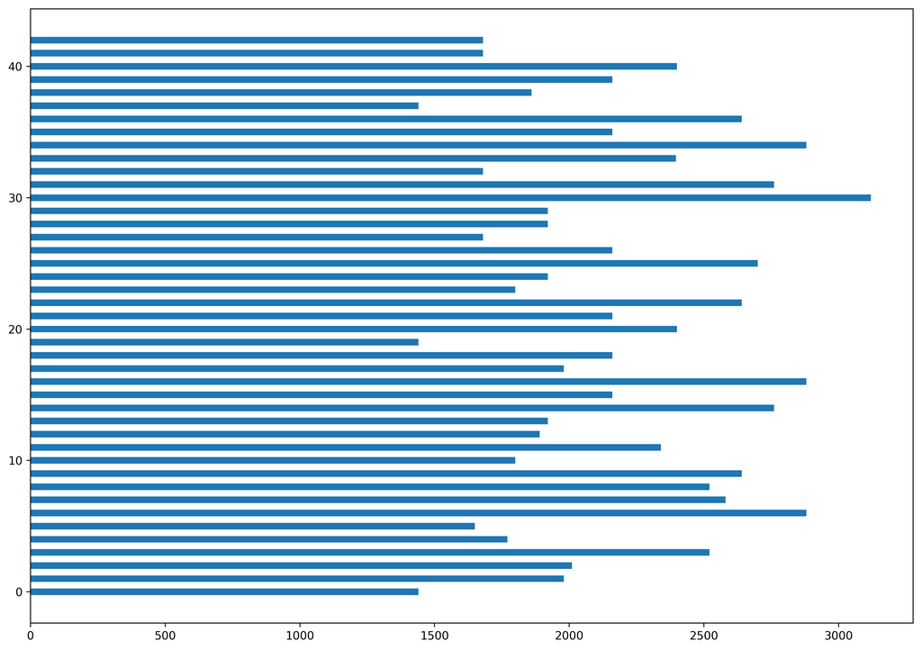

```python
sign_classes, class_indices, class_counts = np.unique(y_train, return_index = True, return_counts = True)
plt.figure(num=None, figsize=(14, 10), dpi=320, facecolor='w', edgecolor='k')
plt.barh(sign_classes, class_counts, height = 0.5)
```

```python
print(X_train.shape)
```

```
(93476, 32, 32, 3)
```

## Step 2: Design and Test a Model Architecture

Design and implement a deep learning model that learns to recognize traffic signs. Train and test your model on the [German Traffic Sign Dataset](http://benchmark.ini.rub.de/?section=gtsrb&subsection=dataset).

The LeNet-5 implementation shown in the classroom at the end of the CNN lesson is a solid starting point. You'll have to change the number of classes and possibly the preprocessing, but aside from that it's plug and play!

With the LeNet-5 solution from the lecture, you should expect a validation set accuracy of about 0.89. To meet specifications, the validation set accuracy will need to be at least 0.93. It is possible to get an even higher accuracy, but 0.93 is the minimum for a successful project submission.

There are various aspects to consider when thinking about this problem:

- Neural network architecture (is the network over or underfitting?)
- Play around preprocessing techniques (normalization, rgb to grayscale, etc)
- Number of examples per label (some have more than others).
- Generate fake data.

Here is an example of a [published baseline model on this problem](http://yann.lecun.com/exdb/publis/pdf/sermanet-ijcnn-11.pdf). It's not required to be familiar with the approach used in the paper but, it's good practice to try to read papers like these.

### Pre-process the Data Set (normalization, grayscale, etc.)

Minimally, the image data should be normalized so that the data has mean zero and equal variance. For image data, `(pixel - 128)/ 128` is a quick way to approximately normalize the data and can be used in this project.

Other pre-processing steps are optional. You can try different techniques to see if it improves performance.

Use the code cell (or multiple code cells, if necessary) to implement the first step of your project.

```python
### Preprocess the data here. It is required to normalize the data. Other preprocessing steps could include
### converting to grayscale, etc.
### Feel free to use as many code cells as needed.
```

```python
# preprocess single image.
from skimage import exposure
def preprocess_image(img):
    new_img = np.copy(img)
    new_img = cv2.cvtColor(new_img, (cv2.COLOR_BGR2YUV))[:,:,0]
    #print(exposure.is_low_contrast(play_img))
    new_img = (new_img / 255.).astype(np.float32)
    #play_img = (exposure.rescale_intensity(play_img))
    #play_img = (exposure.equalize_hist(play_img))
    new_img = (exposure.equalize_adapthist(new_img))
    new_img = (exposure.adjust_sigmoid(new_img))
    #play_img = (exposure.adjust_log(play_img))
    new_img = new_img.reshape(new_img.shape + (1,))
    return new_img

# preprocess a dataset
def preprocess_images(images):
    #print(images.shape)
    new_images = np.zeros((images.shape[0], images.shape[1], images.shape[2], 1)).astype(np.float32)
    #print(new_images.shape)
    for i, img in enumerate(images):
        #print(images[i].shape)
        new_images[i] = preprocess_image(images[i])
    return new_images
```

```python
X_train = preprocess_images(X_train)
X_valid = preprocess_images(X_valid)
X_test = preprocess_images(X_test)

d = {"features":X_train.astype('float32'),"labels":y_train  }
dataset_name = "train_new.p"
with open(dataset_name, 'wb') as handle:
    pickle.dump(d, handle, protocol=pickle.HIGHEST_PROTOCOL)
del d

d = {"features":X_valid.astype('float32'),"labels":y_valid  }
dataset_name = "valid_new.p"
with open(dataset_name, 'wb') as handle:
    pickle.dump(d, handle, protocol=pickle.HIGHEST_PROTOCOL)
del d

d = {"features":X_test.astype('float32'),"labels":y_test  }
dataset_name = "test_new.p"
with open(dataset_name, 'wb') as handle:
    pickle.dump(d, handle, protocol=pickle.HIGHEST_PROTOCOL)
del d

print('pre-processing done!')
```

```
pre-processing done!
```

```python
# Some random preprocessed images
def preprocess_image_test(img):
    new_img = np.copy(img)
    new_img = cv2.cvtColor(new_img, (cv2.COLOR_BGR2YUV))[:,:,0]
    #print(exposure.is_low_contrast(play_img))
    new_img = (new_img / 255.).astype(np.float32)
    #play_img = (exposure.rescale_intensity(play_img))
    #play_img = (exposure.equalize_hist(play_img))
    new_img = (exposure.equalize_adapthist(new_img))
    new_img = (exposure.adjust_sigmoid(new_img))
    #play_img = (exposure.adjust_log(play_img))
    #new_img = new_img.reshape(new_img.shape + (1,))
    return new_img
```

[figure not shown]

[figure not shown]

[figure not shown]

[figure not shown]

[figure not shown]

[figure not shown]

[figure not shown]

[figure not shown]

[figure not shown]

[figure not shown]

```python
for i in range(10):
    index = np.random.randint(0, len(X_train))
    fig = plt.figure()
    img = X_train[index]
    img_prep = preprocess_image_test(img)

    axis = fig.add_subplot(1, 2, 1, xticks=[], yticks=[])
    axis.imshow(img)

    axis = fig.add_subplot(1, 2, 2, xticks=[], yticks=[])
    axis.imshow(img_prep, cmap='gray')
```

```python
print(X_train[1].shape)
print(X_train.shape)
```

```
(32, 32, 1)
(93476, 32, 32, 1)
```

```python
from sklearn.utils import shuffle

X_train, y_train = shuffle(X_train, y_train)
```

### Model Architecture

```python
x = tf.placeholder(tf.float32, (None, 32, 32, 1))
y = tf.placeholder(tf.int32, (None))
one_hot_y = tf.one_hot(y, n_classes)
is_training = tf.placeholder(tf.bool)
```

```python
rate = 0.001
beta = 0.0003

# Arguments used for tf.truncated_normal, randomly defines variables for the weights and biases for each layer
mu = 0
sigma = 0.1

weights = [
    tf.Variable(tf.truncated_normal((3, 3, 1, 12), mean = mu, stddev = sigma)),
    tf.Variable(tf.truncated_normal((4, 4, 12, 32), mean = mu, stddev = sigma)),
    tf.Variable(tf.truncated_normal((5, 5, 32, 64), mean = mu, stddev = sigma)),
    tf.Variable(tf.truncated_normal((1600, 1028), mean = mu, stddev = sigma)),
    tf.Variable(tf.truncated_normal((1028, 512), mean = mu, stddev = sigma)),
    tf.Variable(tf.truncated_normal((512, 256), mean = mu, stddev = sigma)),
    tf.Variable(tf.truncated_normal((256, n_classes), mean = mu, stddev = sigma))
]
biases = [
   tf.Variable(tf.zeros(12)),
   tf.Variable(tf.zeros(32)),
   tf.Variable(tf.zeros(64)),
   tf.Variable(tf.zeros(1028)),
   tf.Variable(tf.zeros(512)),
    tf.Variable(tf.zeros(256)),
   tf.Variable(tf.zeros(n_classes))
]
```

```python
### Define your architecture here.
### Feel free to use as many code cells as needed.
from tensorflow.contrib.layers import flatten
import tensorflow as tf

def LeNet(x, weights, biases, is_training):
    if is_training is not None:
        print ("Training phase -> perform Dropout")
    else:
        print ("Evalutation phase -> not performing Dropout")

    layer = 0

    # TODO: Layer 1: Convolutional. Input = 32x32x3. Output = 28x28x6.
    conv_1 = tf.nn.conv2d(x, weights[layer], strides = [1, 1, 1, 1], padding = 'VALID') + biases[layer]
    # TODO: Activation.
    conv_1 = tf.nn.relu(conv_1)
    # TODO: Pooling. Input = 28x28x6. Output = 14x14x6.
    pool_1 = tf.nn.max_pool(conv_1, ksize = [1, 2, 2, 1], strides = [1, 1, 1, 1], padding = 'VALID')
    pool_1 = tf.cond(is_training, lambda: tf.nn.dropout(pool_1, keep_prob = 0.9), lambda: pool_1)
    print('1 = ', pool_1.shape)
    layer += 1

    # TODO: Layer 2: Convolutional. Output = 10x10x16.
    conv_2 = tf.nn.conv2d(pool_1, weights[layer], [1, 1, 1, 1], 'VALID') + biases[layer]
    # TODO: Activation.
    conv_2 = tf.nn.relu(conv_2)
    # TODO: Pooling. Input = 10x10x16. Output = 5x5x16.
    pool_2 = tf.nn.max_pool(conv_2, ksize = [1, 2, 2, 1], strides = [1, 1, 1, 1], padding = 'VALID')
    pool_2 = tf.cond(is_training, lambda: tf.nn.dropout(pool_2, keep_prob = 0.9), lambda: pool_2)
    # TODO: Flatten. Input = 5x5x16. Output = 400.
    #flatten_input = flatten(pool_2)
    print('1 = ', pool_2.shape)

    layer += 1

    # TODO: Layer 2: Convolutional. Output = 10x10x16.
    conv_3 = tf.nn.conv2d(pool_2, weights[layer], [1, 2, 2, 1], 'VALID') + biases[layer]
    # TODO: Activation.
    conv_3 = tf.nn.relu(conv_3)
    # TODO: Pooling. Input = 10x10x16. Output = 5x5x16.
    pool_3 = tf.nn.max_pool(conv_3, ksize = [1, 2, 2, 1], strides = [1, 2, 2, 1], padding = 'VALID')
    pool_3 = tf.cond(is_training, lambda: tf.nn.dropout(pool_3, keep_prob = 0.8), lambda: pool_3)
    print('1 = ', pool_3.shape)
    # TODO: Flatten. Input = 5x5x16. Output = 400.
    flatten_input = flatten(pool_3)
    print(flatten_input.shape)
    layer += 1

    # TODO: Layer 3: Fully Connected. Input = 400. Output = 120.
    dense_1 = tf.matmul(flatten_input, weights[layer]) + biases[layer]
    # TODO: Activation.
    dense_1 = tf.nn.relu(dense_1)
    dense_1 = tf.cond(is_training, lambda: tf.nn.dropout(dense_1, keep_prob = 0.7), lambda: dense_1)

    layer += 1

    # TODO: Layer 4: Fully Connected. Input = 120. Output = 84.
    dense_2 = tf.matmul(dense_1, weights[layer]) + biases[layer]
    dense_2 = tf.nn.relu(dense_2)
    dense_2 = tf.cond(is_training, lambda: tf.nn.dropout(dense_2, keep_prob = 0.6), lambda: dense_2)

    layer += 1

    # TODO: Layer 4: Fully Connected. Input = 120. Output = 84.
    dense_3 = tf.matmul(dense_2, weights[layer]) + biases[layer]
    dense_3 = tf.nn.relu(dense_3)
    dense_3 = tf.cond(is_training, lambda: tf.nn.dropout(dense_3, keep_prob = 0.5), lambda: dense_3)

    layer += 1
    logits = tf.matmul(dense_3, weights[layer]) + biases[layer]
    return logits
```

```python
X_conv_1_test = X_train[1].reshape((1, 32, 32, 1))
print(LeNet(X_conv_1_test, weights, biases, is_training)[0].shape)
```

```
Training phase -> perform Dropout
1 =  (1, 29, 29, 12)
1 =  (1, 25, 25, 32)
1 =  (1, 5, 5, 64)
(1, 1600)
(43,)
```

```python
logits = LeNet(x, weights, biases, is_training)
cross_entropy = tf.nn.softmax_cross_entropy_with_logits_v2(labels=one_hot_y, logits=logits)

# l2 regularization
regularizer = tf.reduce_sum([tf.nn.l2_loss(w) for w in weights])
loss_operation = tf.reduce_mean(cross_entropy + beta * regularizer)
optimizer = tf.train.AdamOptimizer(learning_rate = rate)
training_operation = optimizer.minimize(loss_operation)
```

```
Training phase -> perform Dropout
1 =  (?, 29, 29, 12)
1 =  (?, 25, 25, 32)
1 =  (?, 5, 5, 64)
(?, 1600)
```

```python
#from preprocessing import inception_preprocessing
#image = tf.placeholder(tf.uint8, shape=(None, None, None, 3))
#def augment_images(img):
#    preprocess = inception_preprocessing.preprocess_image(image, height=299, width=299, is_training=True)
#    return sess.run(preprocess, feed_dict = {image: img})

correct_prediction = tf.equal(tf.argmax(logits, 1), tf.argmax(one_hot_y, 1))
accuracy_operation = tf.reduce_mean(tf.cast(correct_prediction, tf.float32))
saver = tf.train.Saver()

def evaluate(X_data, y_data):
    num_examples = len(X_data)
    total_accuracy = 0
    sess = tf.get_default_session()
    for offset in range(0, num_examples, BATCH_SIZE):
        batch_x, batch_y = X_data[offset:offset+BATCH_SIZE], y_data[offset:offset+BATCH_SIZE]
        accuracy = sess.run(accuracy_operation, feed_dict={x: batch_x, y: batch_y, is_training: False})
        total_accuracy += (accuracy * len(batch_x))
    return total_accuracy / num_examples
```

```python
global best_accuracy
best_accuracy = 0.0
```

```python
EPOCHS = 5
BATCH_SIZE = 128
with tf.Session() as sess:
    #sess.run(tf.global_variables_initializer())
    saver.restore(sess, tf.train.latest_checkpoint('.'))
    num_examples = len(X_train)

    print("Training...")
    print()
    for i in range(EPOCHS):
        X_train, y_train = shuffle(X_train, y_train)
        for offset in range(0, num_examples, BATCH_SIZE):
            end = offset + BATCH_SIZE
            batch_x, batch_y = X_train[offset:end], y_train[offset:end]
            sess.run(training_operation, feed_dict={x: batch_x, y: batch_y, is_training: True})
        training_accuracy = evaluate(X_train, y_train)
        validation_accuracy = evaluate(X_valid, y_valid)
        print("EPOCH {} ...".format(i+1))
        print("Validation Accuracy = {:.3f}, Training Accuracy = {:.3f}".format(validation_accuracy, training_accuracy))
        print()

        if (validation_accuracy > best_accuracy):
            best_accuracy = validation_accuracy
            saver.save(sess, './lenet')
            print("Model saved")
    print("Training finished")
```

```
INFO:tensorflow:Restoring parameters from .\lenet
Training...

EPOCH 1 ...
Validation Accuracy = 0.988, Training Accuracy = 0.996

EPOCH 2 ...
Validation Accuracy = 0.986, Training Accuracy = 0.995

EPOCH 3 ...
Validation Accuracy = 0.990, Training Accuracy = 0.995

EPOCH 4 ...
Validation Accuracy = 0.984, Training Accuracy = 0.993

EPOCH 5 ...
Validation Accuracy = 0.987, Training Accuracy = 0.997

Training finished
```

```python
print('Best validation accuracy = ', best_accuracy)
```

```
Best validation accuracy =  0.990702948116
```

### Train, Validate and Test the Model

A validation set can be used to assess how well the model is performing. A low accuracy on the training and validation sets imply underfitting. A high accuracy on the training set but low accuracy on the validation set implies overfitting.

```python
### Train your model here.
### Calculate and report the accuracy on the training and validation set.
### Once a final model architecture is selected,
### the accuracy on the test set should be calculated and reported as well.
### Feel free to use as many code cells as needed.
with tf.Session() as sess:
    saver.restore(sess, tf.train.latest_checkpoint('.'))

    test_accuracy = evaluate(X_test, y_test)
    print("Test Accuracy = {:.3f}".format(test_accuracy))
```

```
INFO:tensorflow:Restoring parameters from .\lenet
Test Accuracy = 0.976
```

## Step 3: Test a Model on New Images

To give yourself more insight into how your model is working, download at least five pictures of German traffic signs from the web and use your model to predict the traffic sign type.

You may find `signnames.csv` useful as it contains mappings from the class id (integer) to the actual sign name.

### Load and Output the Images

```python
### Load the images and plot them here.
### Feel free to use as many code cells as needed.
def get_label_string(lb):
    return sign_names.iloc[lb].get('SignName')

def test_new_image(img_path, label):
    img = cv2.imread(img_path)
    img = cv2.cvtColor(img, cv2.COLOR_BGR2RGB)
    plt.imshow(img)
    std_im = cv2.resize(img, (32, 32))
    std_im = preprocess_image(std_im)
    std_im = std_im.reshape((1, 32, 32, 1))
    with tf.Session() as sess:
        saver.restore(sess, './lenet')
        pred = sess.run(tf.argmax(logits, 1), feed_dict = {x: std_im, is_training: False})[0]
    is_correct = (pred == label)
    pred = get_label_string(pred)
    label = get_label_string(label)
    print('This is the image of sign :{0}, Predicted sign: {1}'.format(label, pred))

def resize_and_preprocess(img_path):
    img = cv2.imread(img_path)
    img = cv2.cvtColor(img, cv2.COLOR_BGR2RGB)
    std_im = cv2.resize(img, (32, 32))
    std_im = preprocess_image(std_im)
    return std_im
```

### Predict the Sign Type for Each Image

```python
### Run the predictions here and use the model to output the prediction for each image.
### Make sure to pre-process the images with the same pre-processing pipeline used earlier.
### Feel free to use as many code cells as needed.
sign_names
```

|  | ClassId | SignName |
| --- | --- | --- |
| 0 | 0 | Speed limit (20km/h) |
| 1 | 1 | Speed limit (30km/h) |
| 2 | 2 | Speed limit (50km/h) |
| 3 | 3 | Speed limit (60km/h) |
| 4 | 4 | Speed limit (70km/h) |
| 5 | 5 | Speed limit (80km/h) |
| 6 | 6 | End of speed limit (80km/h) |
| 7 | 7 | Speed limit (100km/h) |
| 8 | 8 | Speed limit (120km/h) |
| 9 | 9 | No passing |
| 10 | 10 | No passing for vehicles over 3.5 metric tons |
| 11 | 11 | Right-of-way at the next intersection |
| 12 | 12 | Priority road |
| 13 | 13 | Yield |
| 14 | 14 | Stop |
| 15 | 15 | No vehicles |
| 16 | 16 | Vehicles over 3.5 metric tons prohibited |
| 17 | 17 | No entry |
| 18 | 18 | General caution |
| 19 | 19 | Dangerous curve to the left |
| 20 | 20 | Dangerous curve to the right |
| 21 | 21 | Double curve |
| 22 | 22 | Bumpy road |
| 23 | 23 | Slippery road |
| 24 | 24 | Road narrows on the right |
| 25 | 25 | Road work |
| 26 | 26 | Traffic signals |
| 27 | 27 | Pedestrians |
| 28 | 28 | Children crossing |
| 29 | 29 | Bicycles crossing |
| 30 | 30 | Beware of ice/snow |
| 31 | 31 | Wild animals crossing |
| 32 | 32 | End of all speed and passing limits |
| 33 | 33 | Turn right ahead |
| 34 | 34 | Turn left ahead |
| 35 | 35 | Ahead only |
| 36 | 36 | Go straight or right |
| 37 | 37 | Go straight or left |
| 38 | 38 | Keep right |
| 39 | 39 | Keep left |
| 40 | 40 | Roundabout mandatory |
| 41 | 41 | End of no passing |
| 42 | 42 | End of no passing by vehicles over 3.5 metric ... |

```
INFO:tensorflow:Restoring parameters from ./lenet
This is the image of sign :Turn right ahead, Predicted sign: Turn right ahead
```

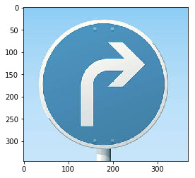

```python
test_new_image('new_images/turn_right.jpg', 33)
```

```
INFO:tensorflow:Restoring parameters from ./lenet
This is the image of sign :No entry, Predicted sign: No entry
```

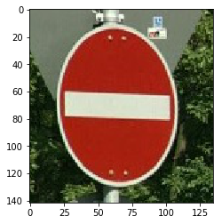

```python
test_new_image('new_images/no_entry.jpg', 17)
```

```
INFO:tensorflow:Restoring parameters from ./lenet
```

```
This is the image of sign :Roundabout mandatory, Predicted sign: Roundabout mandatory
```

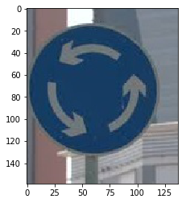

```python
test_new_image('new_images/roundabout.jpg', 40)
```

```
INFO:tensorflow:Restoring parameters from ./lenet
```

```
This is the image of sign :Bicycles crossing, Predicted sign: Bicycles crossing
```

[figure not shown]

```python
test_new_image('new_images/bicycles_crossing.jpg', 29)
```

```
INFO:tensorflow:Restoring parameters from ./lenet
```

```
This is the image of sign :Road work, Predicted sign: Road work
```

[figure not shown]

```python
test_new_image('new_images/road_works.jpg', 25)
```

### Analyze Performance

```python
### Calculate the accuracy for these 5 new images.
### For example, if the model predicted 1 out of 5 signs correctly, it's 20% accurate on these new images.
import os
image_dir = 'new_images/'
new_image_paths = os.listdir('./'+image_dir)
print(new_image_paths)
new_images = np.zeros((5, 32, 32, 1), dtype = np.float32)
for i in range(len(new_image_paths)):
    new_images[i] = resize_and_preprocess(image_dir + new_image_paths[i])
new_labels = [29, 17, 25, 40, 33]
with tf.Session() as sess:
    saver.restore(sess, tf.train.latest_checkpoint('.'))

    test_accuracy = evaluate(new_images, new_labels)
    print("Test Accuracy = {:.3f}".format(test_accuracy))
```

```
['bicycles_crossing.jpg', 'no_entry.jpg', 'road_works.jpg', 'roundabout.jpg', 'turn_right.jpg']
INFO:tensorflow:Restoring parameters from .\lenet
```

```
Test Accuracy = 1.000
```